Saad Mufti

CS 539 - HW 5

# **Conceptual and Theoretical Questions**

### **Q1 (10 pts)**

Kullback-Leibler Divergence is given as: $$KL(p||q)=-\int{p(x)\ln\left(\frac{p(x)}{q(x)}\right)}$$

And the PDF of a Multivariate Gaussian $N$ is: $$N_{PDF}=\det(2\pi\Sigma)^{-\frac{1}{2}}\exp\left(-\frac{1}{2}(x-\mu)^T\Sigma^{-1}(x-\mu)\right)$$

Notice that the KL Divergence is also equivalent to $$E_{p}\left[\frac{\ln(p)}{\ln(q)}\right]$$

Using the definition of expectation.

Where $k$ is the dimensionality of the Gaussians.

### **Q2 (10 pts)**

Take the KL Divergence formula, replacing $q$ with the normal PDF: $$KL(p||N(x|\mu,\Sigma)) = -\int{p(x)\ln\frac{p(x)}{\det(2\pi\Sigma)^{-\frac{1}{2}}\exp\left(-\frac{1}{2}(x-\mu)^T\Sigma^{-1}(x-\mu)\right)}}$$

Take the partial derivatives with respect to $\Sigma$ and $\mu$ and set them to 0 to find their minimizing expressions.

Take the partial with respect to $\mu$: $$\frac{\partial}{\partial\mu} p(x)\ln\left(\det(2\pi\Sigma)^{-\frac{1}{2}}\exp\left(-\frac{1}{2}(x-\mu)^T\Sigma^{-1}(x-\mu)\right)\right)$$

$$0=\Sigma^{-1}\mu-\Sigma^{-1}E_{p}[x]$$$$E_p[x]=\mu$$

And with respect to $\Sigma$:

$$\frac{\partial}{\partial\Sigma} p(x)\ln\left(\det(2\pi\Sigma)^{-\frac{1}{2}}\exp\left(-\frac{1}{2}(x-\mu)^T\Sigma^{-1}(x-\mu)\right)\right)$$$$\Sigma=E[xx^T] - \mu\mu^T = E_p[xx^T] - E_p[x]E_p[x^T] = cov_p[x]$$

Thus, the optimal Normal distribution to approximate some other distribution, which would minimize their KL divergence, would be the Normal whose mean is its target's expectation and whose covariance is that of its target.

### **Q3 (10 pts)**

Rewrite $p(t|x,w)$ as:

$$\prod_i^N\det(2\pi\Sigma)^{-\frac{1}{2}}\exp\left(-\frac{1}{2}(t_i-y(x_i,w))^T\Sigma^{-1}(t_i-y(x_i,w))\right)$$

Which is our likelihood function.

Simplify with the log-likelihood: $$\propto\sum_i^N\ln\det(\Sigma)^{-\frac{1}{2}}-\frac{1}{2}(t_i-y(x_i,w))^T\Sigma^{-1}(t_i-y(x_i,w))$$

$$= -\frac{1}{2}\sum_i^N\ln\det(\Sigma)+(t_i-y(x_i,w))^T\Sigma^{-1}(t_i-y(x_i,w))$$

If $\Sigma$ is fixed and known, we can remove the first term in the above equation to get:

$$\frac{1}{2}\sum_i^N(t_i-y(x_i,w))^T\Sigma^{-1}(t_i-y(x_i,w))$$

To find the maximum likelihood expression for $\Sigma$, take the derivative of the error function with respect to $\Sigma$, set it to 0, and solve for $\Sigma$.

### **Q4 (10 pts)**

Rewrite $z$ as $z=e^u$ to simplify further calculations, since $x^2 = uv$ and $x^2y = u$.

$$\frac{\partial z}{\partial u} = \frac{\partial}{\partial u} e^{u} = e^u$$$$\frac{\partial z}{\partial v} = \frac{\partial}{\partial v} e^{u} = 0 $$

If $u$ and $v$ are the tunable parameters for $z$, their update rules would be

$$u^{(n+1)} \leftarrow u^{(n)} - \eta \frac{\partial E}{\partial u}$$$$v^{(n+1)} \leftarrow v^{(n)} - \eta \frac{\partial E}{\partial v}$$

Calculate the derivatives: $$\frac{\partial E}{\partial u} = -\frac{\partial z}{\partial u} \cdot (t-e^u) = -e^u \cdot (t-e^u)$$

$$\frac{\partial E}{\partial v} = -\frac{\partial z}{\partial v} \cdot (t-e^u) = 0$$

Since $E$ is not a function of $v$, its update rule is meaningless since changing $v$ will not affect the error function. That is also why $\frac{\partial E}{\partial v}=0$.

The update rule for $u$ would become:

$$u^{(n+1)} \leftarrow u^{(n)} + \eta e^u (t-e^u)$$

Note I use $E$ as the error function to avoid confusion with euler's constant.

# **Application Questions**

```python
# Imports
from numpy import *
import pandas as pd
from scipy import integrate
from scipy.stats import norm

from sklearn.manifold import TSNE
from sklearn.neural_network import MLPClassifier
from sklearn.model_selection import cross_val_score

import matplotlib.pyplot as plt
```

### **KL Distance (20 pts)**

```python
# Part a
n_sam = 200
def p(x):
    return 1/3 * norm(-1, 2).pdf(x) + 2/3 * norm(1, 1).pdf(x)
def q(x, m, s):
    return norm(m, s).pdf(x)

def sample_p():
    samples = []
    sels = random.choice([0, 1], p=[1/3, 2/3], size=n_sam)
    for i in sels:
        mu, var = (-1, 2) if i == 0 else (1, 1)
        samples.append(random.normal(mu, var))
    return samples

def kl_distance(m, s, q):
    def eq(x):
        return log(p(x)) - log(q(x, m, s))
    return sum(eq(sample_p())) / n_sam

s_range = linspace(1, 3, num=50)
m_range = linspace(-2, 2, num=50)

dists = zeros((len(m_range), len(s_range)))

for i, m in enumerate(m_range):
    for j, s in enumerate(s_range):
        dists[i, j] = kl_distance(m, s, q)

# print(dists)
print("Mean of computed KL distances: ", round(dists.mean(), 5))
print(f"Min = {round(dists.min(), 5)}, Max = {round(dists.max(), 5)}")
```

[output not shown]

```
Min KL = 0.0126, with:
m = 0.3673,
s = 1.6939
```

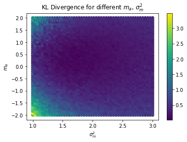

```python
fig_kl_a, ax_kl_a = plt.subplots()

X_s, Y_m = meshgrid(s_range, m_range)

scatter = ax_kl_a.scatter(X_s, Y_m, c=dists)
ax_kl_a.set_ylabel(r"$m_a$")
ax_kl_a.set_xlabel(r"$\sigma^2_m$")
ax_kl_a.set_title(r"KL Divergence for different $m_a$, $\sigma^2_m$")
fig_kl_a.colorbar(scatter, ax=ax_kl_a)

min_dist = round(dists.min(), 5)
arg_md = unravel_index(argmin(dists, axis=None), dists.shape)
est_min_m = Y_m[arg_md]
est_min_s = X_s[arg_md]
print(f"Min KL = {min_dist}, with:\nm = {round(est_min_m, 4)},\ns = {round(est_min_s, 4)}")
```

```python
# Part b
exp_p = integrate.quad(lambda x: x * p(x), -inf, inf)[0]
var_p = integrate.quad(lambda x: (x ** 2) * p(x), -inf, inf)[0] - exp_p ** 2

print("Expectation of p(x): ", round(exp_p, 5))
print("Variance of p(x): ", round(var_p, 5))
print("KL(p || q(E[p], Var[p]) = ", round(kl_distance(exp_p, var_p, q), 5))
```

```
Expectation of p(x):  0.33333
Variance of p(x):  2.88889
KL(p || q(E[p], Var[p]) =  0.26308
```

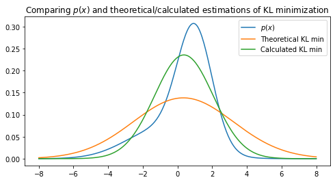

```python
fig_dist_comp, ax_dist_comp = plt.subplots(figsize=(8,4))

x_space = linspace(-8, 8, num=300)
ax_dist_comp.plot(x_space, p(x_space), label="$p(x)$")
ax_dist_comp.plot(x_space, q(x_space, exp_p, var_p), label="Theoretical KL min")
ax_dist_comp.plot(x_space, q(x_space, est_min_m, est_min_s), label="Calculated KL min")
ax_dist_comp.set_title("Comparing $p(x)$ and theoretical/calculated estimations of KL minimization")
ax_dist_comp.legend()
```

### **TSNE (20 pts)**

```python
# Load training set predictors
ds_root = r"UCI HAR Dataset/UCI HAR Dataset"
features = pd.read_csv(f"{ds_root}/features_dup.txt", delimiter=" ", header=None, names=["feature"])
features = features.to_numpy().T.flatten()
x_train = pd.read_csv(f"{ds_root}/train/X_train_pp.txt", delimiter=" ", header=None, names=features)

x_train.head()
```

|  | tBodyAcc-mean()-X | tBodyAcc-mean()-Y | tBodyAcc-mean()-Z | tBodyAcc-std()-X | tBodyAcc-std()-Y | tBodyAcc-std()-Z | tBodyAcc-mad()-X | tBodyAcc-mad()-Y | tBodyAcc-mad()-Z | tBodyAcc-max()-X | ... | fBodyBodyGyroJerkMag-meanFreq() | fBodyBodyGyroJerkMag-skewness() | fBodyBodyGyroJerkMag-kurtosis() | angle(tBodyAccMean,gravity) | angle(tBodyAccJerkMean),gravityMean) | angle(tBodyGyroMean,gravityMean) | angle(tBodyGyroJerkMean,gravityMean) | angle(X,gravityMean) | angle(Y,gravityMean) | angle(Z,gravityMean) |
| --- | --- | --- | --- | --- | --- | --- | --- | --- | --- | --- | --- | --- | --- | --- | --- | --- | --- | --- | --- | --- | --- |
| 0 | 0.288585 | -0.020294 | -0.132905 | -0.995279 | -0.983111 | -0.913526 | -0.995112 | -0.983185 | -0.923527 | -0.934724 | ... | -0.074323 | -0.298676 | -0.710304 | -0.112754 | 0.030400 | -0.464761 | -0.018446 | -0.841247 | 0.179941 | -0.058627 |
| 1 | 0.278419 | -0.016411 | -0.123520 | -0.998245 | -0.975300 | -0.960322 | -0.998807 | -0.974914 | -0.957686 | -0.943068 | ... | 0.158075 | -0.595051 | -0.861499 | 0.053477 | -0.007435 | -0.732626 | 0.703511 | -0.844788 | 0.180289 | -0.054317 |
| 2 | 0.279653 | -0.019467 | -0.113462 | -0.995380 | -0.967187 | -0.978944 | -0.996520 | -0.963668 | -0.977469 | -0.938692 | ... | 0.414503 | -0.390748 | -0.760104 | -0.118559 | 0.177899 | 0.100699 | 0.808529 | -0.848933 | 0.180637 | -0.049118 |
| 3 | 0.279174 | -0.026201 | -0.123283 | -0.996091 | -0.983403 | -0.990675 | -0.997099 | -0.982750 | -0.989302 | -0.938692 | ... | 0.404573 | -0.117290 | -0.482845 | -0.036788 | -0.012892 | 0.640011 | -0.485366 | -0.848649 | 0.181935 | -0.047663 |
| 4 | 0.276629 | -0.016570 | -0.115362 | -0.998139 | -0.980817 | -0.990482 | -0.998321 | -0.979672 | -0.990441 | -0.942469 | ... | 0.087753 | -0.351471 | -0.699205 | 0.123320 | 0.122542 | 0.693578 | -0.615971 | -0.847865 | 0.185151 | -0.043892 |

5 rows × 561 columns

```python
# Load training set labels
y_train = pd.read_csv(f"{ds_root}/train/y_train.txt", header=None, names=["Labels"])
y_train = y_train.to_numpy().T.flatten()
y_train
```

```
array([5, 5, 5, ..., 2, 2, 2], dtype=int64)
```

```python
# Part a
tsne = TSNE(n_components=2, learning_rate="auto", init="pca")
x_train_red = tsne.fit_transform(x_train)
```

[output not shown]

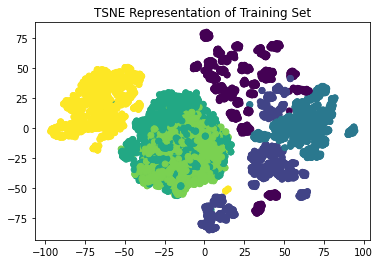

```python
_, ax_tsne_a = plt.subplots()
ax_tsne_a.set_title("TSNE Representation of Training Set")
ax_tsne_a.scatter(*x_train_red.T, c=y_train)
```

```python
# Part b - load testing set
x_test = pd.read_csv(f"{ds_root}/test/X_test_pp.txt", delimiter=" ", header=None, names=features)
x_test.head()
```

|  | tBodyAcc-mean()-X | tBodyAcc-mean()-Y | tBodyAcc-mean()-Z | tBodyAcc-std()-X | tBodyAcc-std()-Y | tBodyAcc-std()-Z | tBodyAcc-mad()-X | tBodyAcc-mad()-Y | tBodyAcc-mad()-Z | tBodyAcc-max()-X | ... | fBodyBodyGyroJerkMag-meanFreq() | fBodyBodyGyroJerkMag-skewness() | fBodyBodyGyroJerkMag-kurtosis() | angle(tBodyAccMean,gravity) | angle(tBodyAccJerkMean),gravityMean) | angle(tBodyGyroMean,gravityMean) | angle(tBodyGyroJerkMean,gravityMean) | angle(X,gravityMean) | angle(Y,gravityMean) | angle(Z,gravityMean) |
| --- | --- | --- | --- | --- | --- | --- | --- | --- | --- | --- | --- | --- | --- | --- | --- | --- | --- | --- | --- | --- | --- |
| 0 | 0.257178 | -0.023285 | -0.014654 | -0.938404 | -0.920091 | -0.667683 | -0.952501 | -0.925249 | -0.674302 | -0.894088 | ... | 0.071645 | -0.330370 | -0.705974 | 0.006462 | 0.162920 | -0.825886 | 0.271151 | -0.720009 | 0.276801 | -0.057978 |
| 1 | 0.286027 | -0.013163 | -0.119083 | -0.975415 | -0.967458 | -0.944958 | -0.986799 | -0.968401 | -0.945823 | -0.894088 | ... | -0.401189 | -0.121845 | -0.594944 | -0.083495 | 0.017500 | -0.434375 | 0.920593 | -0.698091 | 0.281343 | -0.083898 |
| 2 | 0.275485 | -0.026050 | -0.118152 | -0.993819 | -0.969926 | -0.962748 | -0.994403 | -0.970735 | -0.963483 | -0.939260 | ... | 0.062891 | -0.190422 | -0.640736 | -0.034956 | 0.202302 | 0.064103 | 0.145068 | -0.702771 | 0.280083 | -0.079346 |
| 3 | 0.270298 | -0.032614 | -0.117520 | -0.994743 | -0.973268 | -0.967091 | -0.995274 | -0.974471 | -0.968897 | -0.938610 | ... | 0.116695 | -0.344418 | -0.736124 | -0.017067 | 0.154438 | 0.340134 | 0.296407 | -0.698954 | 0.284114 | -0.077108 |
| 4 | 0.274833 | -0.027848 | -0.129527 | -0.993852 | -0.967445 | -0.978295 | -0.994111 | -0.965953 | -0.977346 | -0.938610 | ... | -0.121711 | -0.534685 | -0.846595 | -0.002223 | -0.040046 | 0.736715 | -0.118545 | -0.692245 | 0.290722 | -0.073857 |

5 rows × 561 columns

```python
# Load testing labels
y_test = pd.read_csv(f"{ds_root}/test/y_test.txt", header=None, names=["Labels"])
y_test = y_test.to_numpy().T.flatten()
y_test
print(y_test.shape)
```

```
(2947,)
```

```python
# Perform t-SNE on testing set
x_test_red = tsne.fit_transform(x_test)
```

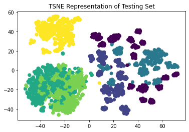

```python
_, ax_tsne_b = plt.subplots()
ax_tsne_b.set_title("TSNE Representation of Testing Set")
ax_tsne_b.scatter(*x_test_red.T, c=y_test)
```

#### **Part c**

The test and training sets bear some similarities, such as around the yellow and greensish data on the left side of the plots. The yellow clusters are relatively far from other groups of points, although the test set's yellow cluster is less consolidated. The same goes for the mix of greenish clusters overlayed on each other, which are roughly the same in both datasets. The turquoise data in the training set are close together, while in the test set, exist in small clusters.

Overall, the similarities between the test and training set are apparent, but there are some notable differences that set them apart.

### **Neural Networks (20 pts)**

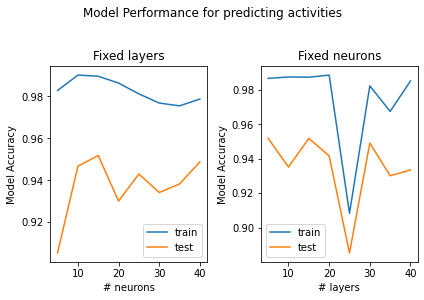

```python
# Part a

fig_perf_a, ax_perf_a = plt.subplots(1, 2)
def nn_perf(l_train, l_test, ax):
    x_space = [5, 10, 15, 20, 25, 30, 35, 40]
    for f in [0, 1]:
        acc_train = []
        acc_test = []
        for i in x_space:
            layers = (i,) * 20 if f == 0 else (20,) * i
            model = MLPClassifier(hidden_layer_sizes=layers, activation="identity")
            model.fit(x_train, l_train)
            acc_train.append(model.score(x_train, l_train))
            acc_test.append(model.score(x_test, l_test))
        ax[f].plot(x_space, acc_train, label="train")
        ax[f].plot(x_space, acc_test, label="test")
        ax[f].set_ylabel("Model Accuracy")
        ax[f].legend()

nn_perf(y_train, y_test, ax_perf_a)
fig_perf_a.suptitle("Model Performance for predicting activities", y=1.03)
ax_perf_a[0].set_title("Fixed layers")
ax_perf_a[1].set_title("Fixed neurons")
ax_perf_a[0].set_xlabel("# neurons")
ax_perf_a[1].set_xlabel("# layers")
fig_perf_a.tight_layout()
```

```python
# Logistic Regression (with no regularization) also performs very well in predicting activities
from sklearn.linear_model import LogisticRegression
lin = LogisticRegression(penalty="none", max_iter=2000).fit(x_train, y_train)
lin.score(x_test, y_test)
```

```
0.9504580929759077
```

```python
# Part b - Load participant data
particip_train = pd.read_csv(f"{ds_root}/train/subject_train.txt", header=None)
particip_train = particip_train.to_numpy().T.flatten()

particip_test = pd.read_csv(f"{ds_root}/test/subject_test.txt", header=None)
particip_test = particip_test.to_numpy().T.flatten()
```

```python
# Combine test/train datasets
X = pd.concat([x_train, x_test])
particip_set = concatenate([particip_train, particip_test])
model_b = MLPClassifier(hidden_layer_sizes=(15,)*2, activation="identity")

cross_val_score(model_b, X, particip_set, cv=10)
```

```
array([0.22135922, 0.27961165, 0.47961165, 0.68543689, 0.71067961,
       0.32330097, 0.24854369, 0.49514563, 0.76601942, 0.6404276 ])
```

**Observations** The subject dataset, on the other hand, was not as simple to train on. Because the test set was comprised of labels the training set did not have, the NN classifier initially had an accuracy of 0, which is why it was necessary to recombine the test and training sets to show the neural network at least some examples of each subject.

The 10-fold cross validation for my chosen model did not give nearly as good accuracies as compared to a). This was the best accuracy I could produce for the models I tried.

My activation function was once again the identity function, and I used 15 neurons in each of 2 layers. I previously tried a larger number of layers, but with worse results.

The accuracy of the folds ranges from 20% to nearly 80%.